# day4_simplifyEnrichment

In this example, we demonstrate simplification of an ORA enrichment analysis.

```r
load("demo_ora.RData")
```

The following function converts gene symbols to Entrez IDs.

```r
convert_to_entrez_id = function(x) {
    if(is.matrix(x)) {
        map = cola:::guess_id_mapping(rownames(x))
        if(is.function(map)) {
            new_rn = map(rownames(x))
        } else {
            new_rn = map[rownames(x)]
        }
        l = is.na(new_rn)

        x = x[!l, , drop = FALSE]
        new_rn = new_rn[!l]

        x2 = do.call(rbind, tapply(1:nrow(x), new_rn, function(ind) {
            colMeans(x[ind, , drop = FALSE])
        }))
        return(x2)

    } else if(is.numeric(x)) {
        map = cola:::guess_id_mapping(names(x))
        x2 = s
        if(is.function(map)) {
            names(x2) = map(names(x))
        } else {
            names(x2) = map[names(x)]
        }
        x2 = x2[!is.na(names(x2))]
        x2 = tapply(x2, names(x2), mean)
        return(x2)
    } else {
        map = cola:::guess_id_mapping(x)
        if(is.function(map)) {
            x2 = map(x)
        } else {
            x2 = map[x]
        }
        x2 = x2[!is.na(x2)]
        x2 = unique(x2)
        return(x2)
    }
}
diff_gene = convert_to_entrez_id(diff_gene)
```

```
## testing org.Hs.egENSEMBL...
## testing org.Hs.egREFSEQ...
## testing org.Hs.egSYMBOL...
##   gene id might be SYMBOL (p = 1.000)
```

We perform ORA analysis with **clusterProfiler**, and extract the list of significant GO terms:

```r
library(clusterProfiler)
library(org.Hs.eg.db)
res = enrichGO(gene = diff_gene, ont = "BP", OrgDb = org.Hs.eg.db)
go_list = res@result$ID[res@result$p.adjust < 0.05]
length(go_list)
```

```
## [1] 676
```

Now we use **simplifyEnrichment** to simplify the reading of the massive number of GO terms.

The use of **simplifyEnrichment** is very simple. There are two steps:

1. calculate semantic similarity
2. perform clustering and visualization

```r
library(simplifyEnrichment)
sim_mat = GO_similarity(go_list)
simplifyGO(sim_mat)
```

```
## Cluster 676 terms by 'binary_cut'... 25 clusters, used 1.695494 secs.
## Perform keywords enrichment for 17 GO lists...
```

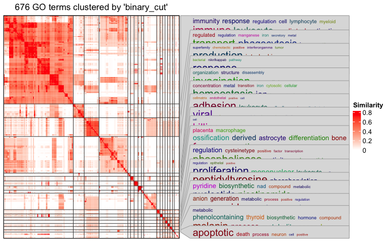

It seems there are too many clusters. There are some clusters actually showing some intermediate similarity. We can adjust the cutoff to decide whether combine or split sub-matrices.

The function `select_cutoff()` tries a list of different cutoffs and plots a diagnostic plot for deciding the optimized cutoff.

```r
select_cutoff(sim_mat)
```

[output not shown]

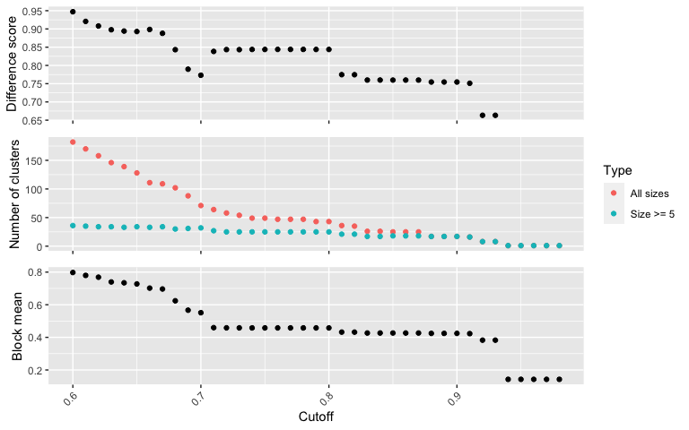

It seems 0.92 or 0.93 is a good one, it decrease the number of clusters, although the difference score decrease a little bit (this means mean similarity within clusters decreases a little bit).

It is also interesting to see when cutoff >= 0.94, all GO terms will be put into a single cluster.

```r
simplifyGO(sim_mat, control = list(cutoff = 0.92))
```

```
## Cluster 676 terms by 'binary_cut'... 8 clusters, used 1.834432 secs.
## Perform keywords enrichment for 8 GO lists...
```

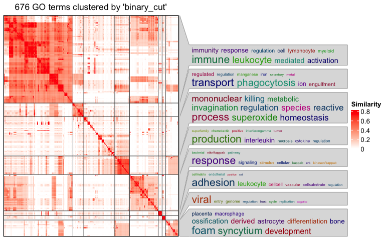

Next we compare multiple GSEA results with **simplifyEnrichment**. We simply generate a ORA results for up-regulated genes and a second ORA results for down-regulated genes.

```r
load("gene_diff_score.RData")
head(gene_diff_score)
```

```
##       10579       56967         177       84991       11151        7490
## -0.03877608 -0.17250784  0.11073309  0.16602936  0.08799365  0.26977336
```

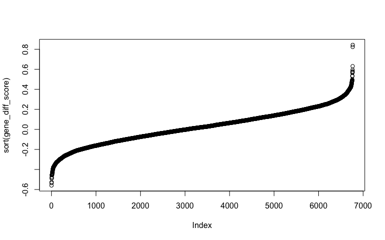

```r
plot(sort(gene_diff_score))
```

Setting `pvalueCutoff = 1` is very important here.

```r
res_up = enrichGO(gene = names(gene_diff_score)[gene_diff_score > 0.2],
    ont = "BP", OrgDb = org.Hs.eg.db, pvalueCutoff = 1)
res_down = enrichGO(gene = names(gene_diff_score)[gene_diff_score < -0.2],
    ont = "BP", OrgDb = org.Hs.eg.db, pvalueCutoff = 1)
```

Extract the “real” result data frames.

```r
tb_up = res_up@result
tb_down = res_down@result
```

Simply pass the two data frames to `simplifyGOFromMultipleLists()`. Note in the function, the column for GO IDs and the column for FDR are automatically detected.

```r
simplifyGOFromMultipleLists(list(up = tb_up, down = tb_down))
```

```
## Use column 'ID' as `go_id_column`.
## Use column 'p.adjust' as `padj_column`.
## 583/6054 GO IDs left for clustering.
## Cluster 583 terms by 'binary_cut'... 26 clusters, used 0.534404 secs.
## Perform keywords enrichment for 7 GO lists...
```

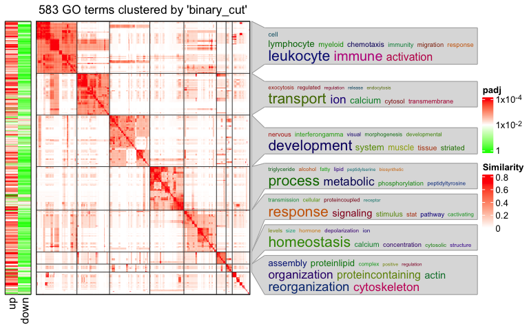